# Kelly Farley Portfolio

### Generalized Linear Model

Below, I use 5 categorical and continuous variables to predict attitudes towards the environment and chose the best model using backwards stepwise regression. An interesting issue I faced was how to determine attitudes about the environment. Individual survey questions indicated positive or negative support for the environment but were skewed. When I averaged the responses to these questions, though, I got a normally distributed composite variable that measured environmental attitudes.

*Driving question*: What makes somebody likely to care about the environment?

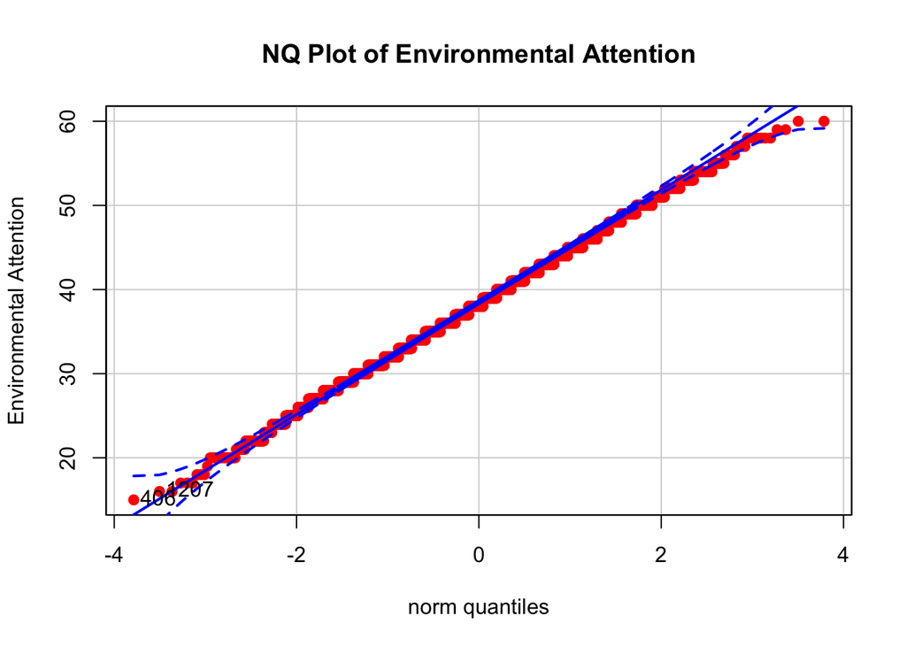

```
## [1]  406 1207
```

```r
# source
source("http://www.reuningscherer.net/s&ds230/Rfuncs/regJDRS.txt")
# import data
envdat <- read.csv("http://reuningscherer.net/s&ds230/data/envdata.csv",
    header = T)
envdat2 <- envdat[envdat$V3 %in% c("6", "12", "18", "19", "20",
    "24", "38"), ]
# recoding numbers to country name
library(car)
envdat2$Country <- recode(envdat2$V3, "6 = 'USA'; 12 = 'Norway'; 18 = 'Russia'; 19 = 'New Zealand'; 20 = 'Canada'; 24 = 'Japan'; 38 = 'Mexico'")
# recoding numbers to sex
envdat2$Gender <- recode(envdat2$V200, "1 = 'Male'; 2 = 'Female'")
# adding years and education to database
envdat2$AgeYears <- envdat2$V201
envdat2$Educ <- envdat2$V204
envdat2$Educ[envdat2$Educ > 30] <- NA  # recoding outliers for education
# recoding employment status
envdat2$EmpStat <- recode(envdat2$V231, "1 = 'Full Time'; 2 = 'Part Time'; 3 = 'Part Time'; 4 = 'With Family'; 8 = 'With Family'; 6 = 'Student'; 7 = 'Retired'; 5 = 'Other'; 9 = 'Other'; 10 = 'Other'")

# this is where it gets interesting: how do we measure
# attitude about the environment? there are a few survey
# questions that indicated higher/lower support of the
# environment, so we will average those scores
sumPos <- rowSums(envdat2[, c("V11", "V13", "V22", "V24", "V26")])
sumNeg <- rowSums(envdat2[, c("V12", "V16", "V17", "V19", "V20",
    "V21", "V23")])
sumTot <- sumPos - sumNeg + 6 * 7
envdat2$EnvAtt <- sumTot
qqPlot(envdat2$EnvAtt, col = "red", pch = 19, ylab = "Environmental Attention",
    main = "NQ Plot of Environmental Attention")
```

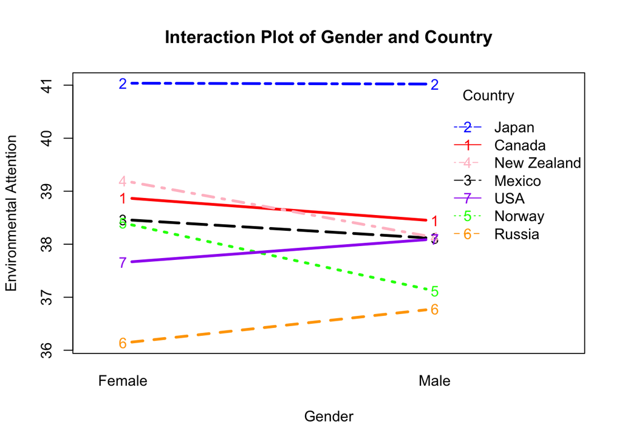

```r
# interestingly, unlike the question answers, this combined
# variable is normally distributed!

# subset of data for what we are interested in
envdat3 <- envdat2[, c((dim(envdat)[2] + 1):(dim(envdat2)[2]))]
envdat3 <- envdat3[complete.cases(envdat3), ]
attach(envdat3)

# determining whether variables have interactions
interaction.plot(Gender, Country, EnvAtt, type = "b", lwd = 3,
    col = c("red", "blue", "black", "pink", "green", "orange",
        "purple"), ylab = "Environmental Attention", main = "Interaction Plot of Gender and Country")
```